# W1. Phenotype data

Bora Kim

March 4, 2021

This is meant for sharing dataset and script of the publication "Strigolactone_structural specificity in microbiome recruitment in rice, 2021". This markdown contains the process of phenotypic data: Biomass and levels of strigolactones (SLs) from 16 genotypes of rice grown two natural soils for 31 days.

## 1. Getting strarted

Load required dataset (samples names on row, phenotypic observation on colunm).

```r
load("W1_phenotype_data_image.Rdata")
meta[1:5,1:5]
```

```
##         Genotype   Soil Compartment Soil_compartment Replicate
## R_A1_e    IAC165  Field        Root            Fi_RT         1
## R_A1_r    IAC165  Field Rhizosphere            Fi_RS         1
## R_A10_e   IAC165 Forest        Root            Fo_RT         5
## R_A10_r   IAC165 Forest Rhizosphere            Fo_RS         5
## R_A2_e    IAC165  Field        Root            Fi_RT         2
```

Load required packages for analysis

```r
library(ggplot2)
library(FSA)
library(rcompanion)
library(dplyr)
library(ggfortify)
library(tibble)
library(reshape2)
```

## 2. Comparing biomass (Fig S1)

To handle data easier, grouping information and biomass were subsetted from initial meta data

```r
bm<-subset(meta[,c(8,1:4)],Compartment=="Root")
bm$Genotype2<-factor(bm$Genotype,
                     c("IAC165", "IAC1246", "GWD", "Dullo","Bina","Sonk","Kinko",
                       "TN1","Bhas","SC","Shiokari","d14","d3","d10","d17","d27")) #change order of genotype for presentation on plot later
```

### 2.1. Kruskal-Wallis test

Test the biomass by soil type and genotype in each soil using non-parametric Kruskal-Wallis test together with P value correction using Benjamini-Hochberg method.

```r
bm_kw<-kruskal.test(bm$total_fresh_biomass_g_per_plant~bm$Soil, data=bm)
bm_kw
```

```
##
##  Kruskal-Wallis rank sum test
##
## data:  bm$total_fresh_biomass_g_per_plant by bm$Soil
## Kruskal-Wallis chi-squared = 103.27, df = 1, p-value < 2.2e-16
```

Create a result table combining all results

```r
bm_kw_res<-as.data.frame(matrix(NA, 1, 4))

bm_kw_res[,1]<-bm_kw$statistic
bm_kw_res[,2]<-bm_kw$parameter
bm_kw_res[,3]<-bm_kw$p.value
bm_kw_res[,4]<-p.adjust(bm_kw$p.value,method="BH" )

colnames(bm_kw_res)<-c("chi_squared", "Df", "P value", "adjusted P value")
rownames(bm_kw_res)<-"Total biomass_by_soil"

bm_kw_res
```

```
##                       chi_squared Df     P value adjusted P value
## Total biomass_by_soil    103.2744  1 2.91797e-24      2.91797e-24
```

### 2.3. Duun test

Compare biomass among genotypes in each soil, therefore subset the biomass from each soil

```r
fobm_dunn<-subset(bm, Soil=="Forest")
PT<-dunnTest(fobm_dunn$total_fresh_biomass_g_per_plant~Genotype, data=fobm_dunn, method = "bh")
fobm_dunn_res<-PT$res
fobm_dunn_res_letter<-cldList(comparison = fobm_dunn_res$Comparison,p.value = fobm_dunn_res$P.adj,threshold  = 0.05)
fobm_dunn_res[1:5,1:4]
```

```
##    Comparison           Z    P.unadj      P.adj
## 1 Bhas - Bina -1.88095303 0.05997831 0.13841148
## 2  Bhas - d10  0.24803776 0.80410519 0.92781368
## 3  Bina - d10  2.12899079 0.03325502 0.08675223
## 4  Bhas - d14  0.06889938 0.94506971 0.96930227
## 5  Bina - d14  1.94985241 0.05119371 0.12286491
```

```r
fobm_dunn_res_letter
```

```
##       Group Letter MonoLetter
## 1      Bhas     ab      ab
## 2      Bina  abcde      abcde
## 3        d1      a      a
## 4       d14     ab      ab
## 5       d17    abc      abc
## 6       d27     ab      ab
## 7        d3      a      a
## 8     Dullo  abcde      abcde
## 9       GWD   abcd      abcd
## 10  IAC1246      e          e
## 11   IAC165      e          e
## 12    Kinko    cde        cde
## 13       SC    cde        cde
## 14 Shiokari     de         de
## 15     Sonk   bcde       bcde
## 16      TN1  abcde      abcde
```

```r
fibm_dunn<-subset(bm, Soil=="Forest")
PT<-dunnTest(fibm_dunn$total_fresh_biomass_g_per_plant~Genotype, data=fibm_dunn, method = "bh")
fibm_dunn_res<-PT$res
fibm_dunn_res_letter<-cldList(comparison = fibm_dunn_res$Comparison,p.value = fibm_dunn_res$P.adj,threshold  = 0.05)
fibm_dunn_res[1:5,1:4]
```

```
##    Comparison           Z    P.unadj      P.adj
## 1 Bhas - Bina -1.88095303 0.05997831 0.13841148
## 2  Bhas - d10  0.24803776 0.80410519 0.92781368
## 3  Bina - d10  2.12899079 0.03325502 0.08675223
## 4  Bhas - d14  0.06889938 0.94506971 0.96930227
## 5  Bina - d14  1.94985241 0.05119371 0.12286491
```

```r
fibm_dunn_res_letter
```

```
##       Group Letter MonoLetter
## 1      Bhas     ab      ab
## 2      Bina  abcde      abcde
## 3        d1      a      a
## 4       d14     ab      ab
## 5       d17    abc      abc
## 6       d27     ab      ab
## 7        d3      a      a
## 8     Dullo  abcde      abcde
## 9       GWD   abcd      abcd
## 10  IAC1246      e          e
## 11   IAC165      e          e
## 12    Kinko    cde        cde
## 13       SC    cde        cde
## 14 Shiokari     de         de
## 15     Sonk   bcde       bcde
## 16      TN1  abcde      abcde
```

### 2.4. Plot biomass

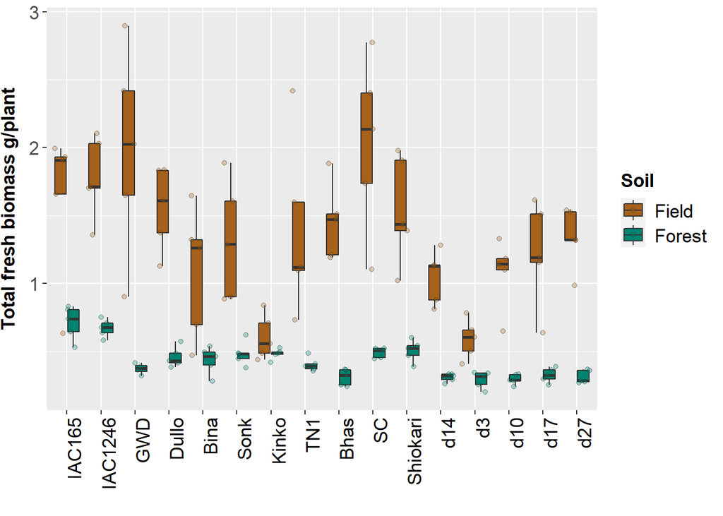

```r
ggplot(bm) +
  geom_boxplot(aes(x=Genotype2, y=total_fresh_biomass_g_per_plant, fill=Soil), outlier.colour = NA)+
  labs(x="", y = "Total fresh biomass g/plant") + scale_fill_manual(values=c("#a6611a","#018571"))+
  geom_point(aes(x=Genotype2, y=total_fresh_biomass_g_per_plant, fill=Soil), alpha = 0.3, shape = 21,
             position = position_jitterdodge())+
  theme(axis.text.x = element_text(size = 13, colour = "black",angle=90, hjust=1),
        axis.text.y = element_text(size = 13),
        axis.title.y = element_text(face = "bold", size = 13, vjust = 3),
        legend.text = element_text(size = 13), legend.title = element_text(size = 13,face = "bold"))
```

## 3. Comparing strigolactone level (figure 1)

As SLs were not detected in field soil, further SL-related studies are only samples obtained from forest soil

```r
foSLs<-subset(meta, Soil_compartment=="Fo_RS"&SL_analysis=="yes")
```

### 3.1. Principle component analysis on three endogenous SLs

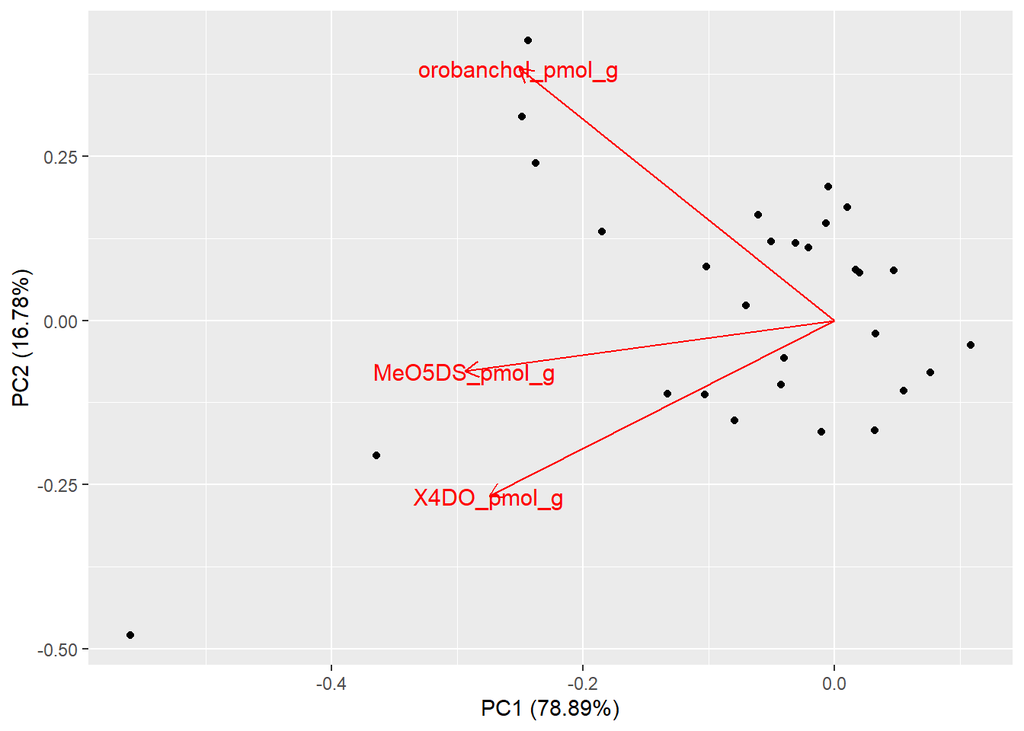

```r
foSLs<-subset(meta, Soil_compartment=="Fo_RS"&SL_analysis=="yes")
foSLs<-subset(meta, Soil_compartment=="Fo_RS"&SL_analysis=="yes")
foSLs_pca<-prcomp(foSLs[11:13], scale. = T)


autoplot(foSLs_pca, data = foSLs_pca, loadings = TRUE,
         loadings.label = TRUE, loadings.label.size = 4)
```

### 3.2. Dunn test

First, remove some genotypes due to zeros in all replicates (non-detectable) which could make problem during Dunn test.

```r
foSLs_dunn<-foSLs %>% filter(!Genotype%in%c('Kinko','TN1','Bhas','SC','d10','d17','d27'))
foSLs_dunn<-foSLs_dunn[,c(11:13,1)]
foSLs_dunn[1:5,1:4]
```

```
##        orobanchol_pmol_g X4DO_pmol_g MeO5DS_pmol_g Genotype
## R_A7_r         0.1201817    5.554455     0.9425109   IAC165
## R_A8_r         0.2420453    9.055589    16.2683221   IAC165
## R_A9_r         0.3023398    5.792403    15.6206970   IAC165
## R_B7_r         0.1252308    0.000000     4.7847343  IAC1246
## R_B8_r         0.2688506    8.246183    16.3267069  IAC1246
```

Perfom Dunn test using loop. As level of MeO5DS was not significantly different among genotype, it was excluded.

```r
indices=2
Z<-as.data.frame(matrix(NA, 36, indices)) #results list =36
P.unadj<-as.data.frame(matrix(NA, 36, indices)) #results list =36
P.adj<-as.data.frame(matrix(NA, 36, indices)) #results list =36
foSLs_dunn_letter<-as.data.frame(matrix(NA, 9, indices)) #results list =9

for(i in 1:indices) {
  PT<-dunnTest(foSLs_dunn[,i]~Genotype, data=foSLs_dunn, method = "bh")
  Z[,i]<-PT$res$Z
  P.unadj[,i]<-PT$res$P.unadj
  P.adj[,i]<-PT$res$P.adj
  PT2<-PT$res
  cl<-cldList(comparison = PT2$Comparison, p.value = PT2$P.adj,threshold  = 0.05)
  foSLs_dunn_letter[,i]<-cl$Letter
}

foSLs_dunn_res<-cbind(Z,P.unadj, P.adj)
rownames(foSLs_dunn_res)<- PT$res$Comparison
colnames(foSLs_dunn_res)<-c("Z_orobanchol","Z_4DO",
                             "unadjusted.P_orobanchol","unadjusted.P_4DO",
                             "adjusted.P_orobanchol","adjusted.P_4DO")
rownames(foSLs_dunn_letter) <- cl$Group
colnames(foSLs_dunn_letter) <- colnames(foSLs_dunn[1:indices])

foSLs_dunn_res[1:5, 1:6]
```

```
##              Z_orobanchol       Z_4DO unadjusted.P_orobanchol unadjusted.P_4DO
## Bina - d14    -0.43210273 -2.44556403              0.66566675      0.014462576
## Bina - d3      1.46434814 -1.24675813              0.14309885      0.212486195
## d14 - d3       1.89645087  1.19880590              0.05790045      0.230603428
## Bina - Dullo  -0.07514975 -0.09650201              0.94009556      0.923121875
## d14 - Dullo    0.40795579  2.63772170              0.68330613      0.008346505
##              adjusted.P_orobanchol adjusted.P_4DO
## Bina - d14               0.7988001      0.1041306
## Bina - d3                0.3030329      0.4249724
## d14 - d3                 0.2084416      0.4150862
## Bina - Dullo             0.9400956      0.9774232
## d14 - Dullo              0.7935168      0.1001581
```

```r
foSLs_dunn_letter
```

```
##          orobanchol_pmol_g X4DO_pmol_g
## Bina                    ab          ab
## d14                     ab           a
## d3                      ab          ab
## Dullo                   ab          ab
## GWD                      a          ab
## IAC1246                  b          ab
## IAC165                   b          ab
## Shiokari                ab           a
## Sonk                    ab           b
```

### 3.3. Plot SLs

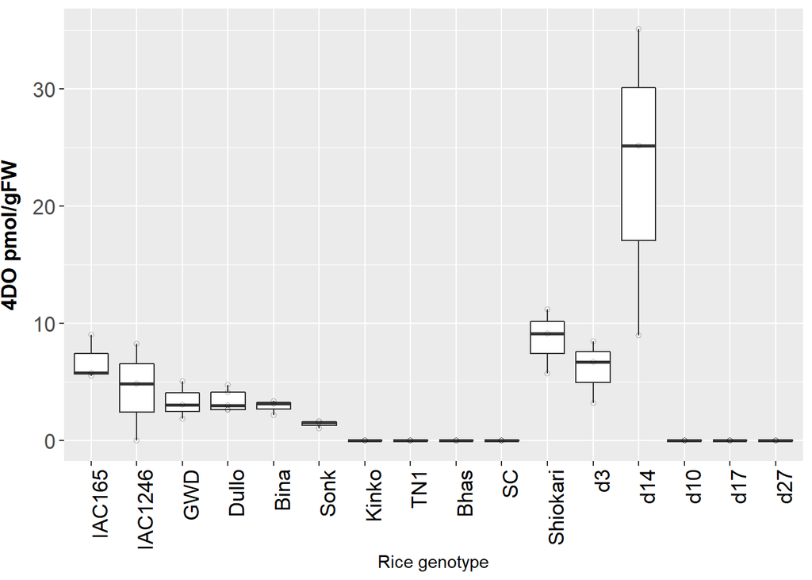

```r
foSLs$Genotype<-droplevels(as.factor(foSLs$Genotype))
foSLs$Genotype2<-factor(foSLs$Genotype,
                         c("IAC165", "IAC1246", "GWD", "Dullo","Bina","Sonk",
                           "Kinko", "TN1","Bhas","SC","Shiokari","d3","d14","d10","d17","d27"))

ggplot(foSLs)+
  geom_boxplot(aes(x=Genotype2, y=X4DO_pmol_g), outlier.colour = NA)+labs(x="Rice genotype", y = "4DO pmol/gFW") +
  geom_point(aes(x=Genotype2, y=X4DO_pmol_g), alpha = 0.3, shape = 21) +
  theme(axis.text.x = element_text(size = 13, colour = "black",angle=90, hjust=1),
        axis.text.y = element_text(size = 13),
        axis.title.y = element_text(face = "bold", size = 13, vjust = 3),
        legend.text = element_text(size = 13), legend.title = element_text(size = 13,face = "bold"))
```